# Bellabeats Market Research Report

## Visualizing the data insights

Visualizing the most active weekdays illustrated the specific days of the week where the activity levels where generally higher. Saturday was the most active day with Sunday being the least active. Traditionally, people work from Monday to Friday and have more free time on Saturday and Sunday.Most people tend to be more active on Saturdays and rest on Sundays before the next work week start.

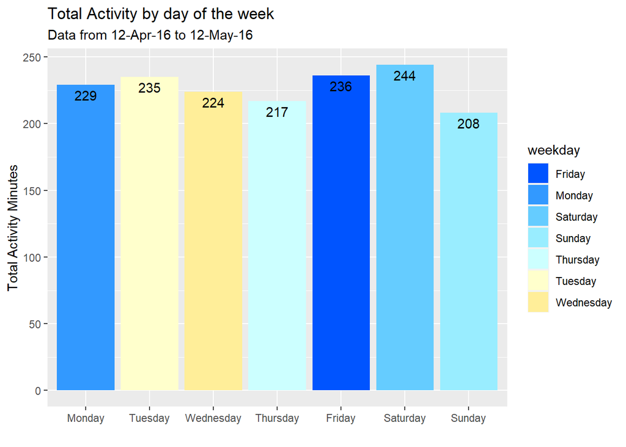

There is a strong correlation between very active minutes and calories used in a day. As seen form the graph below:

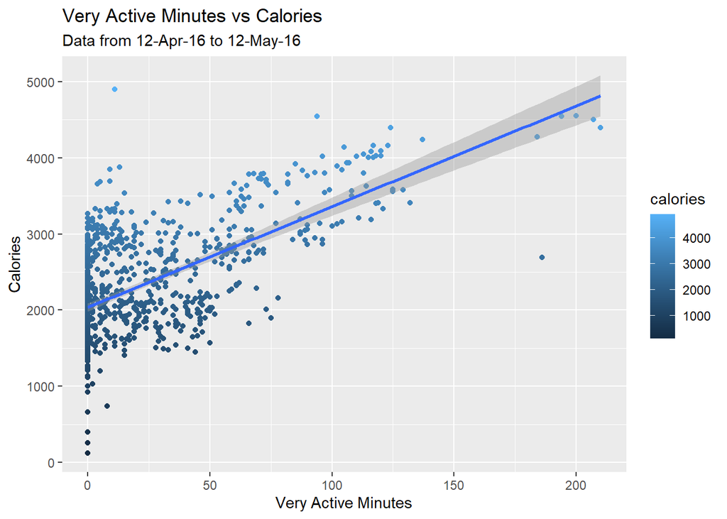

The total active minutes and calorie usage is also correlated although it is interesting to note that the correlation is not as strong as with very active minutes.

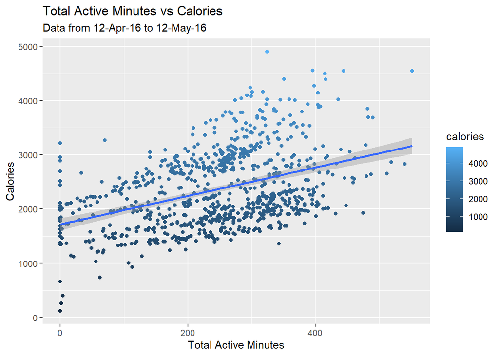

FitBit makes use of METs which is a metric of activity minutes based on the graph below. It illustrates that their algorithm rewards more METs point to more vigorous activities and thus the correlation between METs is a strong compared to the total active minutes as seen below:

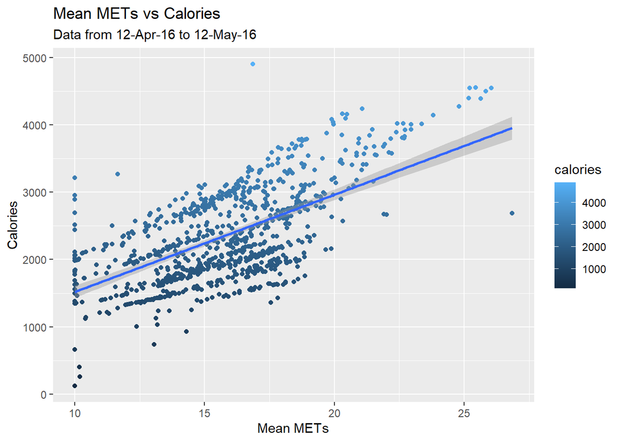

Total step shows a strong correlation against calories burned during the day which is intuitive as the more you walk the more calories you will burn.

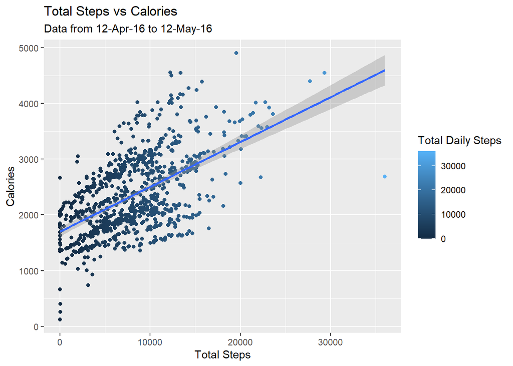

The group slept less than the recommended 7 to 9 hour as prescribe by the CDC for adults with a mean of 6.3 hours of sleep per day.

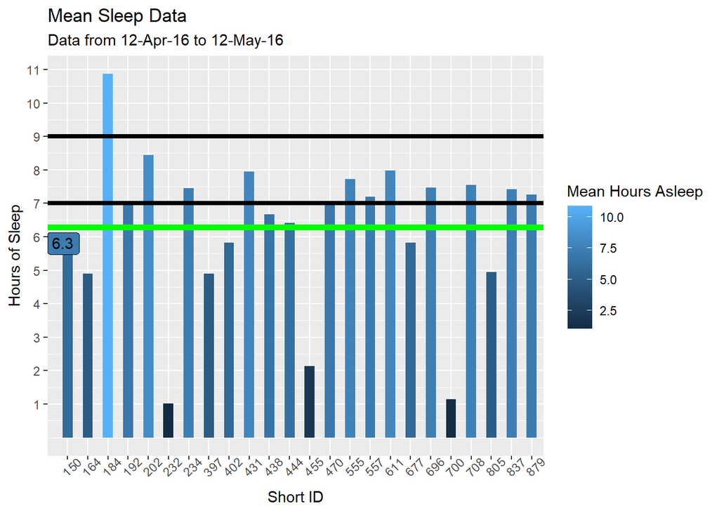

### Recommendation based on the Analysis

The limited sleep data provides an opportunity for the app developers. In order to improve the ‘sleep tracking function’ suggestions can be offered to the users when they are getting too little sleep compared to the 7 to 9 hours of sleep which is recommended by the CDC. Additionally, a follow-up survey can be provided to the participants in an attempt to understand why they did not constantly sleep with their fitness device.

Based on the analysis the fitness devices used during the collection of the data was primaryily used for daily activity tracking and the two products that Bellabeats marketing team can focus on are the ‘Bellabeats Leaf’ and ‘Bellabbeats Time’. Based on my experience with fitness devices one of the best features personalizing your fitness goals with your device. With that being said the app can focus on rewarding vigorous activities especially if the produce is being used for weight loss. Similarly Bellabeats can implement an activity metric such as METs or activity minutes which aligns with the CDC recommendations. Rewarding the user once they have achieved the minimum activity of 22 minutes and increasing the reward points as they increase pass the 22 minutes mark.